# 第8章 製品開発

更新日：2021-05-25 21:22:20

## データ

#### conjoint1.txt

|  | カードNo. | X6時間 | X4時間 | X2年 | 赤 | シルバー | 選好順位 | 全体効用 |
| --- | --- | --- | --- | --- | --- | --- | --- | --- |
| 1 | 1 | 1 | 0 | 0 | 1 | 0 | 7 | 12 |
| 2 | 2 | 1 | 0 | 0 | 0 | 1 | 9 | 10 |
| 3 | 3 | 1 | 0 | 0 | 0 | 0 | 17 | 2 |
| 4 | 4 | 1 | 0 | 1 | 1 | 0 | 1 | 18 |
| 5 | 5 | 1 | 0 | 1 | 0 | 1 | 6 | 13 |
| 6 | 6 | 1 | 0 | 1 | 0 | 0 | 8 | 11 |

#### conjoint2.txt

|  | 回答者id | カードNo. | X2年 | X6時間 | X4時間 | 赤 | シルバー | 全体効用 | 順位 |
| --- | --- | --- | --- | --- | --- | --- | --- | --- | --- |
| 1 | 1 | 1 | 1 | 1 | 0 | 1 | 0 | 9 | 1 |
| 2 | 1 | 2 | 1 | 0 | 1 | 0 | 1 | 7 | 3 |
| 3 | 1 | 3 | 1 | 0 | 0 | 0 | 0 | 3 | 7 |
| 4 | 1 | 4 | 0 | 1 | 0 | 0 | 1 | 5 | 5 |
| 5 | 1 | 5 | 0 | 0 | 1 | 0 | 0 | 2 | 8 |
| 6 | 1 | 6 | 0 | 0 | 0 | 1 | 0 | 4 | 6 |

## 4.2 個人分析

```r
result1 <- lm(全体効用 ~ X2年 + X4時間 + X6時間 + シルバー + 赤, data = conjoint1)
summary(result1)
```

```
##
## Call:
## lm(formula = 全体効用 ~ X2年 + X4時間 + X6時間 + シルバー + 赤,
##     data = conjoint1)
##
## Residuals:
##     Min      1Q  Median      3Q     Max
## -3.0556 -0.8889  0.4167  1.0278  2.4444
##
## Coefficients:
##             Estimate Std. Error t value Pr(>|t|)
## (Intercept)  -0.5556     1.0199  -0.545  0.59591
## X2年          6.7778     0.8327   8.139 3.15e-06 ***
## X4時間        2.5000     1.0199   2.451  0.03052 *
## X6時間        3.5000     1.0199   3.432  0.00497 **
## シルバー      6.3333     1.0199   6.210 4.52e-05 ***
## 赤            7.6667     1.0199   7.517 7.07e-06 ***
## ---
## Signif. codes:  0 '***' 0.001 '**' 0.01 '*' 0.05 '.' 0.1 ' ' 1
##
## Residual standard error: 1.766 on 12 degrees of freedom
## Multiple R-squared:  0.9227, Adjusted R-squared:  0.8905
## F-statistic: 28.65 on 5 and 12 DF,  p-value: 2.819e-06
```

- 重回帰分析（`lm` 関数）でコンジョイント分析を行う場合，部分効用や重要度は手計算かExcelを利用した方が早い。グラフ化も同様。
- conjoint パッケージを利用すれば，直行表の作成から部分効用，重要度の計算まで一括で行うことができる。

## 5.3 集計分析

```r
result2 <- lm(全体効用 ~ X2年 + X4時間 + X6時間 + シルバー + 赤, data = conjoint2)
summary(result2)
```

```
##
## Call:
## lm(formula = 全体効用 ~ X2年 + X4時間 + X6時間 + シルバー + 赤,
##     data = conjoint2)
##
## Residuals:
##     Min      1Q  Median      3Q     Max
## -2.7667 -0.6875 -0.1500  0.5833  2.7000
##
## Coefficients:
##             Estimate Std. Error t value Pr(>|t|)
## (Intercept)   0.1667     0.3193   0.522 0.603020
## X2年          2.2500     0.2560   8.790 1.57e-13 ***
## X4時間        1.1333     0.2956   3.834 0.000243 ***
## X6時間        0.3667     0.2956   1.240 0.218245
## シルバー      3.9000     0.2956  13.194  < 2e-16 ***
## 赤            4.6000     0.2956  15.563  < 2e-16 ***
## ---
## Signif. codes:  0 '***' 0.001 '**' 0.01 '*' 0.05 '.' 0.1 ' ' 1
##
## Residual standard error: 1.145 on 84 degrees of freedom
## Multiple R-squared:  0.8165, Adjusted R-squared:  0.8056
## F-statistic: 74.77 on 5 and 84 DF,  p-value: < 2.2e-16
```

## 参考：conjoint パッケージによる分析

### 全組み合わせ

```r
library(conjoint)

# 属性・水準の定義
attribute <- list(色 = c("赤", "シルバー", "黒"),
                  保証期間 = c("1年", "2年"),
                  バッテリ = c("6時間", "4時間", "2時間"))

# ラベル名
label_name <- c("赤", "シルバー", "黒", "1年", "2年", "6時間", "4時間", "2時間")

# コンジョイントカードの作成（全組み合わせ）
experiment <- expand.grid(attribute)
full <- caFactorialDesign(experiment, type = "full")
print(full)

# コンジョイント分析の実行（全組み合わせ）
Conjoint(conjoint1$全体効用, full, label_name, y.type = "score")
```

```
##          色 保証期間 バッテリ
## 1        赤      1年    6時間
## 2  シルバー      1年    6時間
## 3        黒      1年    6時間
## 4        赤      2年    6時間
## 5  シルバー      2年    6時間
## 6        黒      2年    6時間
## 7        赤      1年    4時間
## 8  シルバー      1年    4時間
## 9        黒      1年    4時間
## 10       赤      2年    4時間
## 11 シルバー      2年    4時間
## 12       黒      2年    4時間
## 13       赤      1年    2時間
## 14 シルバー      1年    2時間
## 15       黒      1年    2時間
## 16       赤      2年    2時間
## 17 シルバー      2年    2時間
## 18       黒      2年    2時間
##
## Call:
## lm(formula = frml)
##
## Residuals:
##     Min      1Q  Median      3Q     Max
## -3,0556 -0,8889  0,4167  1,0278  2,4444
##
## Coefficients:
##                     Estimate Std. Error t value Pr(>|t|)
## (Intercept)           9,5000     0,4164  22,817 2,98e-11 ***
## factor(x$色)1         3,0000     0,5888   5,095 0,000264 ***
## factor(x$色)2         1,6667     0,5888   2,831 0,015161 *
## factor(x$保証期間)1  -3,3889     0,4164  -8,139 3,15e-06 ***
## factor(x$バッテリ)1   1,5000     0,5888   2,547 0,025584 *
## factor(x$バッテリ)2   0,5000     0,5888   0,849 0,412414
## ---
## Signif. codes:  0 '***' 0,001 '**' 0,01 '*' 0,05 '.' 0,1 ' ' 1
##
## Residual standard error: 1,766 on 12 degrees of freedom
## Multiple R-squared:  0,9227, Adjusted R-squared:  0,8905
## F-statistic: 28,65 on 5 and 12 DF,  p-value: 2,819e-06
##
## [1] "Part worths (utilities) of levels (model parameters for whole sample):"
##      levnms    utls
## 1 intercept     9,5
## 2        赤       3
## 3  シルバー  1,6667
## 4        黒 -4,6667
## 5       1年 -3,3889
## 6       2年  3,3889
## 7     6時間     1,5
## 8     4時間     0,5
## 9     2時間      -2
## [1] "Average importance of factors (attributes):"
## [1] 42,72 37,77 19,50
## [1] Sum of average importance:  99,99
## [1] "Chart of average factors importance"
```

**重要度**

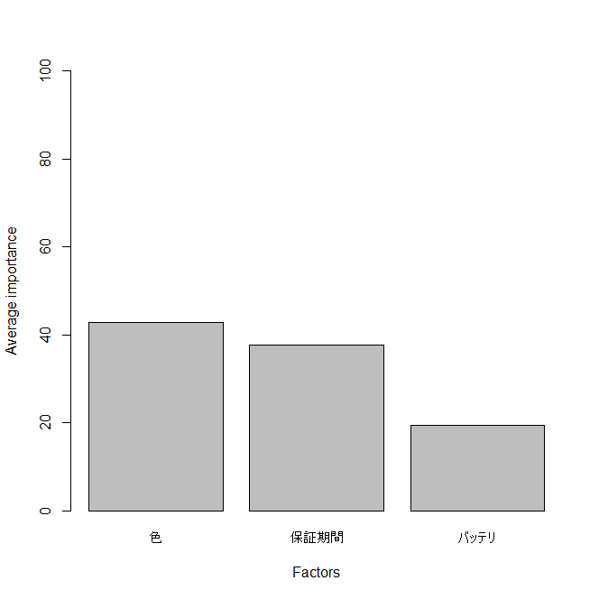

**部分効用・色**

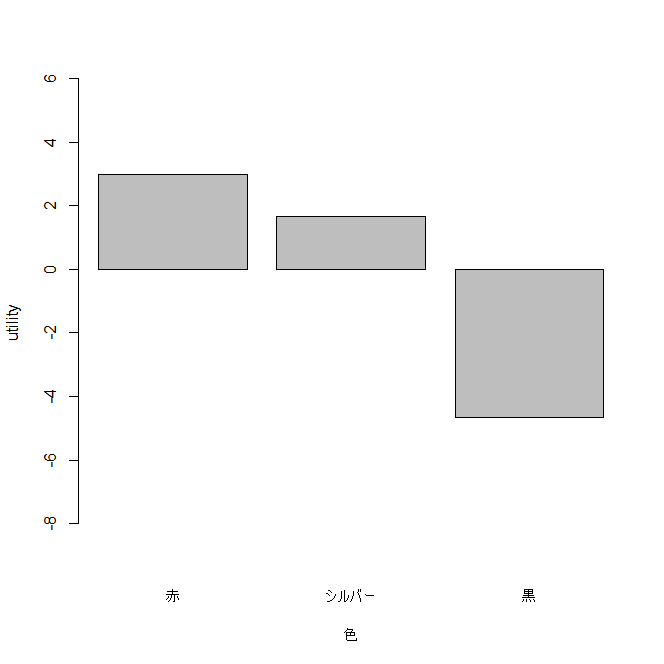

**部分効用・保証**

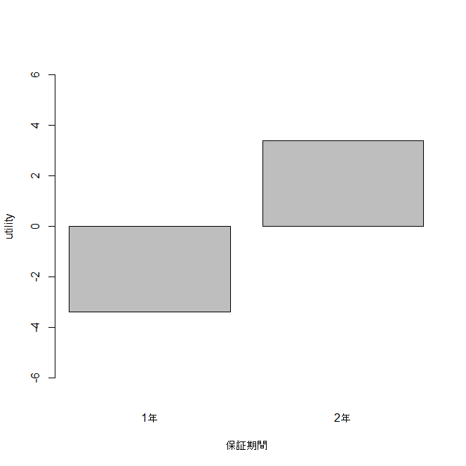

**部分効用・バッテリ**

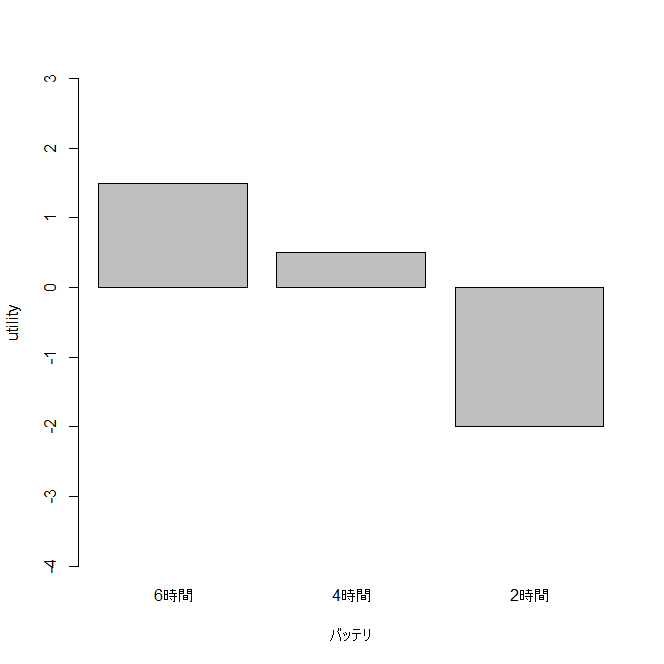

- conjoint パッケージの回帰分析では部分効用（平均偏差形）が直接推定される
- 基準水準を含む部分効用（平均偏差形）は “Part worths (utilities) of levels (model parameters for whole sample):”
- 重要度は “Average importance of factors (attributes):”

### 直行表の利用

```r
library(conjoint)

# 属性・水準の定義
attribute <- list(色 = c("赤", "シルバー", "黒"),
                  保証期間 = c("1年", "2年"),
                  バッテリ = c("6時間", "4時間", "2時間"))

# コンジョイントカードの作成（直行表）
experiment <- expand.grid(attribute)
orth <- caFactorialDesign(experiment, type = "orthogonal")
print(orth)
```

```
##          色 保証期間 バッテリ
## 1        赤      1年    6時間
## 3        黒      1年    6時間
## 5  シルバー      2年    6時間
## 7        赤      1年    4時間
## 12       黒      2年    4時間
## 14 シルバー      1年    2時間
## 15       黒      1年    2時間
## 16       赤      2年    2時間
```

- 教科書の直行表と conjoint パッケージで作成される直行表は若干異なり，教科書データを使った分析ができないため，ここでは直行表の作成方法の紹介までする
- 直行表を使った集計分析の方法は conjoint パッケージのヘルプ（Rで `??conjoint` を実行）を参照するか，ネットで検索
- **教科書の表8.7 ~ 8.10の直行表の一部は間違っているようなので利用しないこと**